# Drake_Zhou_Part_02_B

Drake Zhou

4/24/2022

# Overview & Preparation

## Package Import

This part is mainly focus on fitting the model with Bayesian function, specifically use rstanarm’sstan_lm() or stan_glm()function to fit full Bayesian linear models with syntax like R’s lm().

```r
library(tidyverse)
library(caret)
library(coefplot)
library(rstanarm)
library(splines)
```

## Data Import

Before I fit into linear models, I want transform the response to log-response and standardized the inputs and outputs especially those continuous inputs.

```r
# Read data
df_all <- readr::read_csv("final_project_train.csv", col_names = TRUE)
# Formate data
standard_df_all <- df_all %>%
  select(starts_with("x")) %>%
  scale(center = TRUE, scale = TRUE) %>%
  as.data.frame() %>%
  tibble::as_tibble() %>%
  mutate(y = log(df_all$response),
         region = factor(df_all$region, levels = c("XX", "YY", "ZZ")),
         customer = factor(df_all$customer, levels = c("A", "B", "D", "E", "G", "Other", "Q", "M", "K")))
```

# Model fitting

Why choose these models?

```r
formula_mod9 <- y ~ ns(xb_01, 3)+ns(xb_03, 3)+ ns(xb_03,3)+ns(xn_01,3)+ns(xn_03,3)+ns(xn_03,3)+ns(xa_01,3)+ns(xa_03,3)+ns(xa_03,3)+ns(xb_04,3)+ns(xb_05,3)+ns(xb_06,3)+ns(xb_07,3)+ns(xb_08,3)+ns(xn_04,3)+ns(xn_05,3)+ns(xn_06,3)+ns(xn_07,3)+ns(xn_08,3)+ns(xa_04,3)+ns(xa_05,3)+ns(xa_06,3)+ns(xa_07,3)+ns(xa_08,3)+ns(xw_01,3)+ns(xw_03,3)+ns(xw_03,3)+ns(xs_01,3)+ns(xs_03,3)+ns(xs_03,3)+ns(xs_04,3)+ns(xs_05,3)+ns(xs_06,3)+region+customer

rstanarm_mod9 <- stan_lm(formula_mod9,
                         data = standard_df_all,
                         prior = R2(location = 0.5),
                         seed = 432123,
                         refresh = 0)
```

```r
rstanarm_mod3 <- stan_lm(y ~ .,
                         data = standard_df_all[c(-36, -35)],
                         prior = R2(location = 0.5),
                         seed = 432123,
                         refresh = 0)
```

# Model Evaluation

## Model #9

```r
rstanarm_mod9 %>% summary()
```

```
##
## Model Info:
##  function:     stan_lm
##  family:       gaussian [identity]
##  formula:      y ~ ns(xb_01, 3) + ns(xb_03, 3) + ns(xb_03, 3) + ns(xn_01, 3) +
##     ns(xn_03, 3) + ns(xn_03, 3) + ns(xa_01, 3) + ns(xa_03, 3) +
##     ns(xa_03, 3) + ns(xb_04, 3) + ns(xb_05, 3) + ns(xb_06, 3) +
##     ns(xb_07, 3) + ns(xb_08, 3) + ns(xn_04, 3) + ns(xn_05, 3) +
##     ns(xn_06, 3) + ns(xn_07, 3) + ns(xn_08, 3) + ns(xa_04, 3) +
##     ns(xa_05, 3) + ns(xa_06, 3) + ns(xa_07, 3) + ns(xa_08, 3) +
##     ns(xw_01, 3) + ns(xw_03, 3) + ns(xw_03, 3) + ns(xs_01, 3) +
##     ns(xs_03, 3) + ns(xs_03, 3) + ns(xs_04, 3) + ns(xs_05, 3) +
##     ns(xs_06, 3) + region + customer
##  algorithm:    sampling
##  sample:       4000 (posterior sample size)
##  priors:       see help('prior_summary')
##  observations: 677
##  predictors:   95
##
## Estimates:
##                 mean   sd   10%   50%   90%
## (Intercept)    1.0    0.4  0.4   1.0   1.5
## ns(xb_01, 3)1  1.0    0.3  0.6   1.0   1.4
## ns(xb_01, 3)2  1.7    1.1  0.4   1.8   3.1
## ns(xb_01, 3)3 -0.3    0.9 -1.5  -0.3   1.0
## ns(xb_03, 3)1 -0.4    0.3 -0.7  -0.4   0.0
## ns(xb_03, 3)2  1.0    0.6  0.3   1.0   1.8
## ns(xb_03, 3)3  1.5    0.8  0.4   1.5   2.5
## ns(xn_01, 3)1  0.3    0.2  0.0   0.3   0.6
## ns(xn_01, 3)2  0.2    0.5 -0.5   0.2   0.8
## ns(xn_01, 3)3 -0.1    0.6 -0.9  -0.1   0.7
## ns(xn_03, 3)1 -0.2    0.2 -0.5  -0.2   0.1
## ns(xn_03, 3)2 -0.2    0.4 -0.7  -0.2   0.4
## ns(xn_03, 3)3 -0.1    0.6 -0.8  -0.1   0.6
## ns(xa_01, 3)1  0.2    0.3 -0.1   0.2   0.5
## ns(xa_01, 3)2  1.6    0.8  0.6   1.6   2.6
## ns(xa_01, 3)3  2.5    1.1  1.1   2.5   4.0
## ns(xa_03, 3)1  0.3    0.3 -0.1   0.3   0.6
## ns(xa_03, 3)2 -1.1    0.7 -2.0  -1.1  -0.3
## ns(xa_03, 3)3 -2.3    1.1 -3.7  -2.3  -0.8
```

[output cut: 175 more lines]

```
## customerB     0.0  1.0   7586
## customerD     0.0  1.0   8134
## customerE     0.0  1.0   8527
## customerG     0.0  1.0   9129
## customerOther 0.0  1.0   7489
## customerQ     0.0  1.0   9297
## customerM     0.0  1.0   8376
## customerK     0.0  1.0   8005
## sigma         0.0  1.0   5698
## log-fit_ratio 0.0  1.0   7612
## R2            0.0  1.0   4296
## mean_PPD      0.0  1.0   4026
## log-posterior 0.4  1.0    716
##
## For each parameter, mcse is Monte Carlo standard error, n_eff is a crude measure of effective sample size, and Rhat is the potential scale reduction factor on split chains (at convergence Rhat=1).
```

```r
posterior_interval(rstanarm_mod9)
```

```
##                         5%           95%
## (Intercept)    0.226059846  1.6857954192
## ns(xb_01, 3)1  0.442155093  1.5738716998
## ns(xb_01, 3)2 -0.006917709  3.5088982385
## ns(xb_01, 3)3 -1.825953970  1.2648719433
## ns(xb_03, 3)1 -0.851146330  0.0897671264
## ns(xb_03, 3)2  0.042460341  1.9918587666
## ns(xb_03, 3)3  0.103057497  2.8311356818
## ns(xn_01, 3)1 -0.040959578  0.7278822895
## ns(xn_01, 3)2 -0.717744767  1.0331918128
## ns(xn_01, 3)3 -1.079281555  0.9379709225
## ns(xn_03, 3)1 -0.604650776  0.1777288606
## ns(xn_03, 3)2 -0.818859807  0.5116228419
## ns(xn_03, 3)3 -1.071543656  0.8485565618
## ns(xa_01, 3)1 -0.221318617  0.6196318720
## ns(xa_01, 3)2  0.321841367  2.8708370855
## ns(xa_01, 3)3  0.627002039  4.3769253205
## ns(xa_03, 3)1 -0.196383316  0.7345140958
## ns(xa_03, 3)2 -2.241766142 -0.0103068215
## ns(xa_03, 3)3 -4.043187574 -0.4258615381
## ns(xb_04, 3)1 -3.030084199 -0.7173450647
## ns(xb_04, 3)2 -7.815620961 -1.8196941591
## ns(xb_04, 3)3 -4.458118808 -1.2286648151
## ns(xb_05, 3)1 -0.060351157  0.9429505612
## ns(xb_05, 3)2 -0.838267702  0.8758945776
## ns(xb_05, 3)3 -0.497726016  1.6435524153
## ns(xb_06, 3)1 -0.842065600  0.5028769934
## ns(xb_06, 3)2 -3.489654694  0.7041139052
## ns(xb_06, 3)3 -1.085949813  0.3533718971
## ns(xb_07, 3)1  0.099208036  0.7763838318
## ns(xb_07, 3)2  0.490620591  2.4899863330
## ns(xb_07, 3)3  0.500188522  1.8767806007
## ns(xb_08, 3)1  0.040546943  0.8370126186
## ns(xb_08, 3)2  0.154721476  2.6153296275
## ns(xb_08, 3)3 -0.060990178  1.8593998282
## ns(xn_04, 3)1 -1.768004482  1.1837589152
## ns(xn_04, 3)2 -3.589614423  5.0591844945
## ns(xn_04, 3)3 -0.169761216  4.1123612889
## ns(xn_05, 3)1  0.045969866  0.9805459702
## ns(xn_05, 3)2 -0.511934764  1.5908449772
```

[output cut: 44 more lines]

```
## ns(xs_06, 3)2 -2.130823811 -0.2621984843
## ns(xs_06, 3)3 -0.694578224  0.0549424247
## regionYY       0.165108463  0.2867341908
## regionZZ      -0.286774186 -0.1335470388
## customerB     -0.233927257  0.0260928725
## customerD     -0.172454731  0.1088252079
## customerE     -0.181819596  0.1032632110
## customerG     -0.194093942 -0.0093392806
## customerOther -0.106806259  0.0949578690
## customerQ     -0.286278969  0.0009496259
## customerM     -0.264258540 -0.0637591142
## customerK      0.184711048  0.4049858227
## sigma          0.295398723  0.3257648948
## log-fit_ratio -0.040776548  0.0266168603
## R2             0.626040111  0.6884297569
```

```r
rstanarm::bayes_R2(rstanarm_mod9) %>% quantile(c(0.05, 0.5, 0.95))
```

```
##        5%       50%       95%
## 0.6260401 0.6590217 0.6884298
```

## Model #3

```r
rstanarm_mod3 %>% summary()
```

```
##
## Model Info:
##  function:     stan_lm
##  family:       gaussian [identity]
##  formula:      y ~ .
##  algorithm:    sampling
##  sample:       4000 (posterior sample size)
##  priors:       see help('prior_summary')
##  observations: 677
##  predictors:   34
##
## Estimates:
##                 mean   sd   10%   50%   90%
## (Intercept)    0.8    0.0  0.8   0.8   0.9
## xb_01          0.1    0.1  0.0   0.1   0.2
## xb_02          0.1    0.1  0.0   0.1   0.1
## xb_03          0.0    0.1 -0.1   0.0   0.1
## xn_01          0.1    0.1  0.0   0.1   0.2
## xn_02          0.0    0.1  0.0   0.0   0.1
## xn_03         -0.1    0.1 -0.2  -0.1   0.0
## xa_01         -0.2    0.1 -0.3  -0.2  -0.1
## xa_02          0.2    0.1  0.1   0.2   0.2
## xa_03          0.0    0.1 -0.1   0.0   0.1
## xb_04         -0.3    0.1 -0.4  -0.3  -0.2
## xb_05          0.0    0.1  0.0   0.0   0.1
## xb_06          0.0    0.0  0.0   0.0   0.1
## xb_07          0.1    0.0  0.1   0.1   0.2
## xb_08          0.1    0.1  0.1   0.1   0.2
## xn_04          0.1    0.1  0.0   0.1   0.2
## xn_05          0.2    0.1  0.1   0.2   0.2
## xn_06          0.1    0.0  0.0   0.1   0.1
## xn_07          0.0    0.0 -0.1   0.0   0.0
## xn_08         -0.1    0.0 -0.2  -0.1   0.0
## xa_04          0.0    0.1 -0.1   0.0   0.1
## xa_05          0.1    0.1  0.0   0.1   0.1
## xa_06          0.0    0.0 -0.1   0.0   0.0
## xa_07          0.0    0.0  0.0   0.0   0.1
## xa_08          0.0    0.1 -0.1   0.0   0.0
## xw_01          0.3    0.1  0.2   0.3   0.4
## xw_02          0.0    0.0 -0.1   0.0   0.0
```

[output cut: 45 more lines]

```
## xw_02         0.0  1.0  6957
## xw_03         0.0  1.0  6618
## xs_01         0.0  1.0  7227
## xs_02         0.0  1.0  6891
## xs_03         0.0  1.0  7406
## xs_04         0.0  1.0  7821
## xs_05         0.0  1.0  7143
## xs_06         0.0  1.0  7614
## sigma         0.0  1.0  6002
## log-fit_ratio 0.0  1.0  5531
## R2            0.0  1.0  5211
## mean_PPD      0.0  1.0  5425
## log-posterior 0.2  1.0   810
##
## For each parameter, mcse is Monte Carlo standard error, n_eff is a crude measure of effective sample size, and Rhat is the potential scale reduction factor on split chains (at convergence Rhat=1).
```

```r
posterior_interval(rstanarm_mod3)
```

```
##                         5%          95%
## (Intercept)    0.809083810  0.855033795
## xb_01         -0.044720354  0.220140259
## xb_02         -0.029740076  0.149701917
## xb_03         -0.103744054  0.139684847
## xn_01         -0.033373379  0.179106999
## xn_02         -0.064122530  0.106495363
## xn_03         -0.188585696 -0.001662542
## xa_01         -0.282295724 -0.027390347
## xa_02          0.056634864  0.247025116
## xa_03         -0.094782265  0.136199595
## xb_04         -0.455886870 -0.163981918
## xb_05         -0.064236008  0.150486701
## xb_06         -0.054463136  0.098403134
## xb_07          0.066606203  0.207677450
## xb_08          0.036115029  0.201433479
## xn_04         -0.034897660  0.239193729
## xn_05          0.082964245  0.257685422
## xn_06          0.003280893  0.133165658
## xn_07         -0.082505527  0.039442721
## xn_08         -0.177956834 -0.030135155
## xa_04         -0.116117091  0.165108909
## xa_05         -0.022281973  0.163345012
## xa_06         -0.098957390  0.044702961
## xa_07         -0.035307549  0.120414441
## xa_08         -0.110567566  0.063036355
## xw_01          0.164265936  0.375153417
## xw_02         -0.099029022  0.059396927
## xw_03         -0.140094603  0.025006588
## xs_01         -0.078106437  0.050928499
## xs_02         -0.126570418  0.003084858
## xs_03         -0.065233245  0.056328899
## xs_04         -0.053784508  0.099919542
## xs_05         -0.086805845  0.062252360
## xs_06         -0.068447841  0.056308466
## sigma          0.355164671  0.389129494
## log-fit_ratio -0.036933348  0.037097012
## R2             0.478959530  0.551822738
```

```r
rstanarm::bayes_R2(rstanarm_mod3) %>% quantile(c(0.05, 0.5, 0.95))
```

```
##        5%       50%       95%
## 0.4789595 0.5170128 0.5518227
```

# Model Selection

### R-squared evaluation

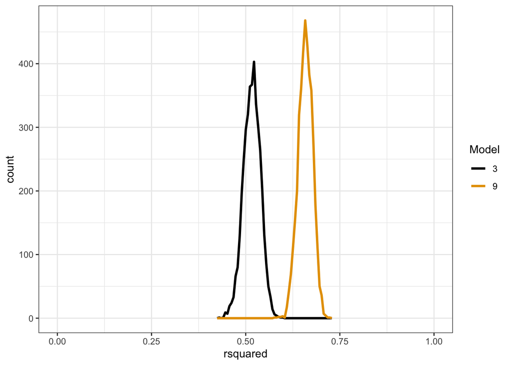

```r
purrr::map2_dfr(list(rstanarm_mod9, rstanarm_mod3),
                as.character(c("9","3")),
                function(mod, mod_name){tibble::tibble(rsquared = bayes_R2(mod)) %>%
                    mutate(model_name = mod_name)}) %>%
  ggplot(mapping = aes(x = rsquared)) +
  geom_freqpoly(bins = 55,
                 mapping = aes(color = model_name),
                 size = 1.1) +
  coord_cartesian(xlim = c(0, 1)) +
  ggthemes::scale_color_colorblind("Model") +
  theme_bw()
```

### WAIC information criterion

According to the WAIC information criterion model 9 is better than model 3

```r
# Calculate performance based on WAIC
rstanarm_mod9$waic <- waic(rstanarm_mod9)
rstanarm_mod3$waic <- waic(rstanarm_mod3)
# Form data
waic_models_perf <- stanreg_list(rstanarm_mod3, rstanarm_mod9,
                          model_names = c("Model 3", "Model 9"))

# Print it out
loo_compare(waic_models_perf, criterion = "waic")
```

```
## Model comparison based on WAIC:
##         elpd_diff se_diff
## Model 9    0.0       0.0
## Model 3 -106.4      15.8
```

### LOOCV

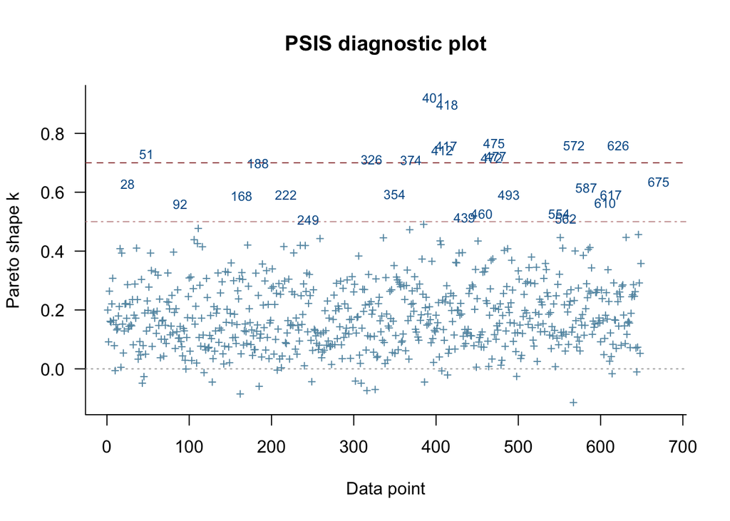

```r
loo_mod9 <- loo(rstanarm_mod9)
plot(loo_mod9, label_points = TRUE)
```

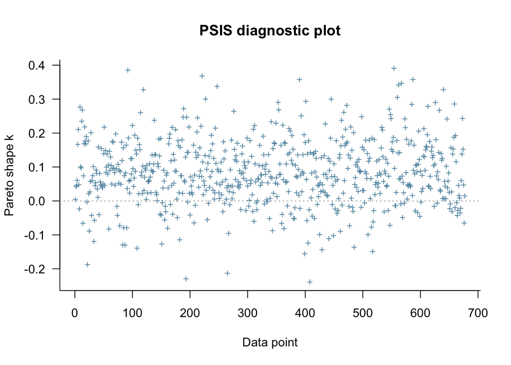

```r
loo_mod3 <- loo(rstanarm_mod3)
plot(loo_mod3, label_points = TRUE)
```

Through the result, model 9 is better than model 3

```r
loo_compare(loo_mod9, loo_mod3)
```

```
##               elpd_diff se_diff
## rstanarm_mod9    0.0       0.0
## rstanarm_mod3 -103.0      16.0
```

# Model Inspection

## Coefficient significance

Extract data.

```r
df_model_09 <- as.data.frame(rstanarm_mod9) %>%
  tibble::as_tibble() %>%
  select(all_of(names(rstanarm_mod9$coefficients)))
```

With so many features, we can’t draw them all that’s meaningless. But we can review several features that we considered important in our previous work. They are not statistically important anymore.

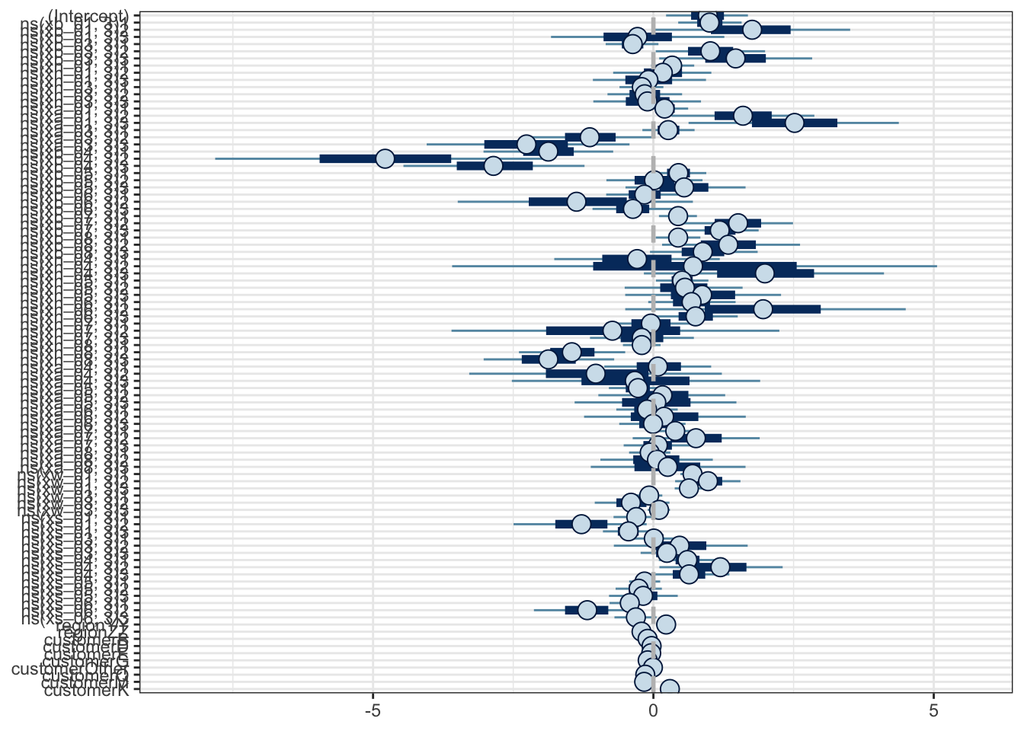

```r
plot(rstanarm_mod9,  pars = names(rstanarm_mod9$coefficients)) +
  geom_vline(xintercept = 0, color = "grey", linetype = "dashed", size = 1.) +
  theme_bw()
```

## Coefficient relation

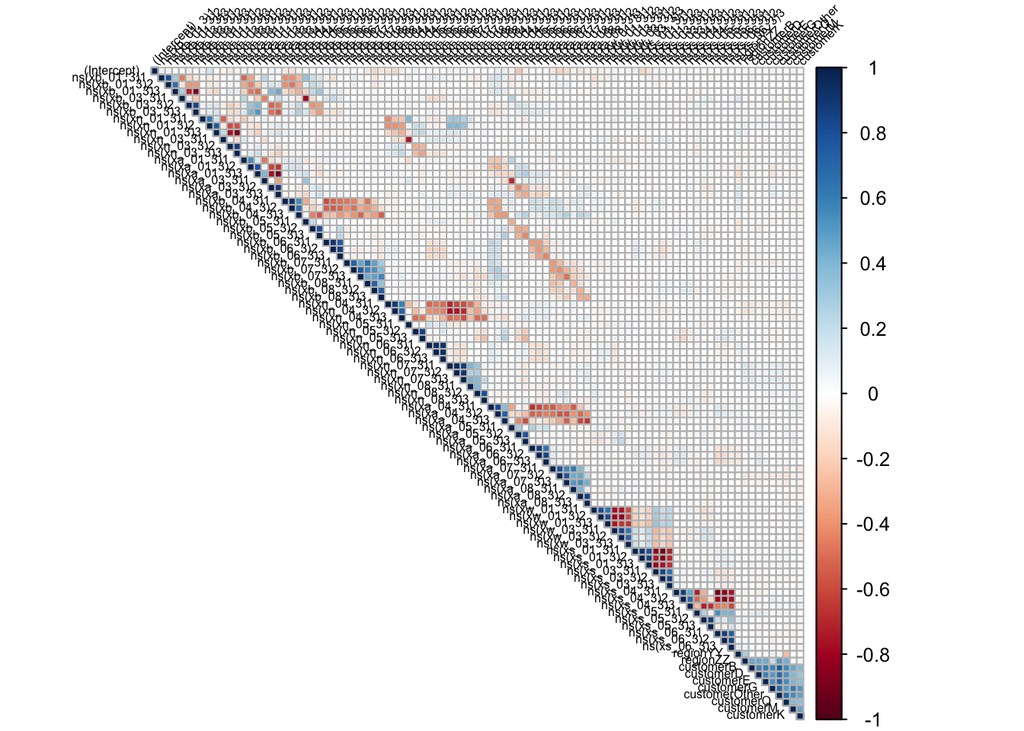

```r
df_model_09 %>%
  cor() %>%
  corrplot::corrplot(method = "square", type = "upper", tl.col = "black", tl.cex = 0.5, tl.srt = 45, cl.lim = c(0, 1))
```

## Variables distribution

Again, since we have too many features, the figure was really messed up. But if we open this figure in a separete windows, which allows us zoom in, we would see all the figure are pretty normal distributed which means is Gaussian distribution.

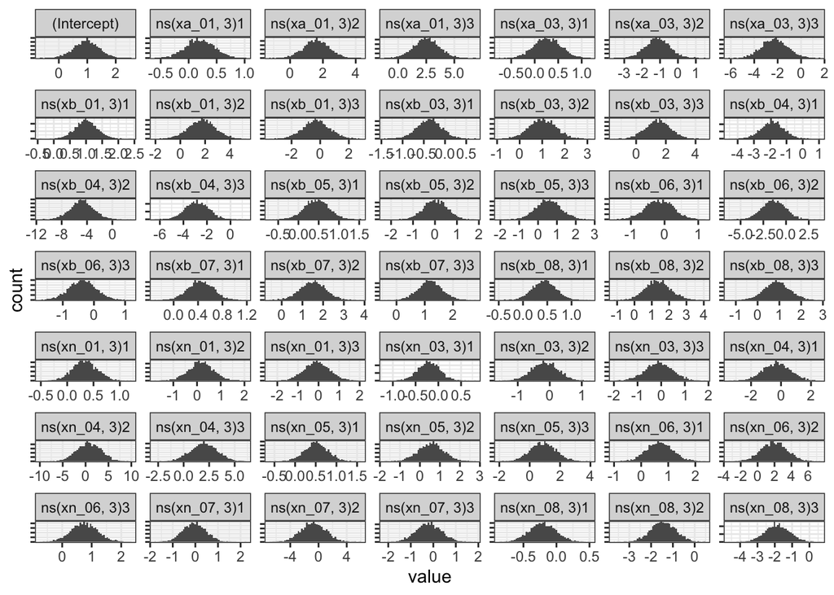

```r
df_model_09[1:49] %>%
  tibble::rowid_to_column("post_id") %>%
  pivot_longer(!c("post_id")) %>%
  ggplot(mapping = aes(x = value)) +
  geom_histogram(bins = 55) +
  facet_wrap(~name, scales = "free") +
  theme_bw() +
  theme(axis.text.y = element_blank())
```

## Sigma uncertainty

And the uncertainty of sigma, with 90% probability that its value is between 0.29 and 0.32, which is relatively very precise sigma.

```r
as.data.frame(rstanarm_mod9) %>% tibble::as_tibble() %>%
  select(sigma) %>%
  pull() %>%
  quantile(c(0.05, 0.5, 0.95))
```

```
##        5%       50%       95%
## 0.2953987 0.3097983 0.3257649
```

Visualize the distribution of sigma

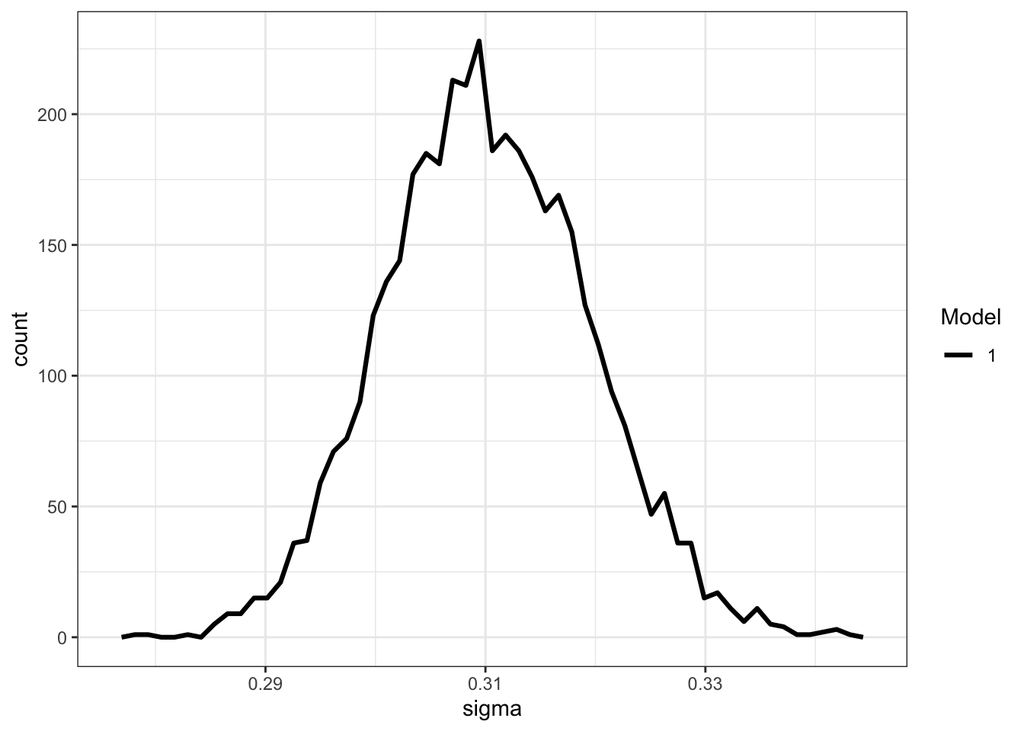

```r
purrr::map2_dfr(list(rstanarm_mod9),
                as.character(1),
                function(mod, mod_name){as.data.frame(mod) %>% tibble::as_tibble() %>%
                    select(sigma) %>%
                    mutate(model_name = mod_name)}) %>%
  ggplot(mapping = aes(x = sigma)) +
  geom_freqpoly(bins = 55,
                 mapping = aes(color = model_name),
                 size = 1.1) +
  ggthemes::scale_color_colorblind("Model") +
  theme_bw()
```

## Compare to MLE

The relationship between Bayesian and non-bayesian, as we can see, Bayesian model has a higher prediction on value of sigma compared to non-bayesian.

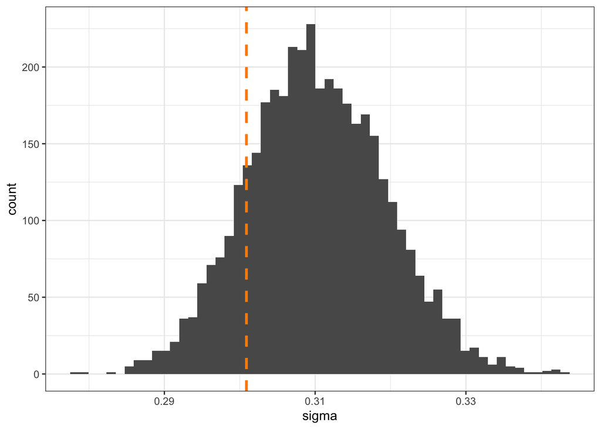

```r
lm_mod9 <- readr::read_rds('models/lm_mod9.rds')

as.data.frame(rstanarm_mod9) %>% tibble::as_tibble() %>%
  ggplot(mapping = aes(x = sigma)) +
  geom_histogram(bins = 55) +
  geom_vline(xintercept = stats::sigma(lm_mod9),
             color = "darkorange", linetype = "dashed", size = 1.1) +
  theme_bw()
```

# Export Models

```r
rstanarm_mod9 %>% readr::write_rds('models/rstanarm_mod9.rds')
rstanarm_mod3 %>% readr::write_rds('models/rstanarm_mod3.rds')
```